# Deskriptive Statistik

Maße der zentralen Tendenz und Streuung

Autor:in

Zugehörigkeit

Daniela Palleschi

Humboldt-Universität zu Berlin

Veröffentlichungsdatum

13. Juni 2023

# Wiederholung

Letzte Woche haben wir…

- etwas über breite und lange Daten gelernt ✅
- breite Daten länger gemacht ✅
- lange Daten breiter gemacht ✅

## 0.1 Überprüfung

```r
pacman::p_load(tidyverse,
               here)
```

```r
df_biondo <- read_csv(here("daten", "biondo_etal_2021_tidy.csv"))
df_billboard <- read_csv(here("daten", "billboard.csv"))
```

```r
df_biondo %>%
  head(n = 5) %>%
  knitr::kable() %>%
  kableExtra::kable_styling(font_size = 20)
```

**1**

Nehmen Sie den Datenrahmen `df_biondo`, und dann

**2**

nimm nur die ersten 5 Zeilen, und dann

**3**

erstelle eine hübsche `knitr`-Tabelle, und dann

**4**

mache die Tabelle noch schöner mit `kableExtra`, mit Schriftgröße 20

| subj | item | tense | verb | gramm | acc | rt | tt |
| --- | --- | --- | --- | --- | --- | --- | --- |
| 1 | 1 | future | representarán | 1 | 1 | 840.1917 | 1596 |
| 1 | 2 | future | alzarán | 1 | 1 | 1310.1809 | 648 |
| 1 | 3 | future | centrarán | 1 | 1 | 700.2674 | 841 |
| 1 | 4 | future | coleccionarán | 1 | 1 | 650.1856 | 1337 |
| 1 | 5 | future | complementarán | 1 | 1 | 580.2159 | 1400 |

- wir wollen normalerweise die Ausgabe von `head()`, `knitr::kable()` und `kableExtra::kable_styling()` nicht als Objekt speichern
  - und schon gar nicht als ein Objekt, das mit `df_` beginnt, was für `dataframe` steht

**Problem**

Zwei Beispiele für dasselbe Problem

```r
df_biondo_long <- df_biondo %>%
  pivot_longer(
    cols = ("rt" | "tt"),
    names_to = "maß",
    values_to = "ms") %>%
  head(n = 10) %>%
  knitr::kable() %>%
  kableExtra::kable_styling()
```

```r
df_biondo_long <- df_biondo %>%
  pivot_longer(
    cols = c(contains("rt"), contains("tt"))
  ) %>%
  knitr::kable() %>%
  kableExtra::kable_styling(font_size = 20)
```

**Lösung 1**

Speichern Sie keine `knitr`-Tabelle, wenn Sie wirklich einen `Datenrahmen` (d.h., `df_`…) speichern wollen. Speichern Sie stattdessen zuerst die `df`, und geben Sie die `df` in einem anderen Codeabschnitt als formatierte Tabelle aus.

```r
# save longer dataframe
df_biondo_long <- df_biondo %>%
  pivot_longer(
    cols = ("rt" | "tt"),
    names_to = "maß",
    values_to = "ms")
```

```r
# print table of longer df
df_biondo_long %>%
  head(n = 10) %>%
  knitr::kable() %>%
  kableExtra::kable_styling(font_size = 20)
```

| subj | item | tense | verb | gramm | acc | maß | ms |
| --- | --- | --- | --- | --- | --- | --- | --- |
| 1 | 1 | future | representarán | 1 | 1 | rt | 840.1917 |
| 1 | 1 | future | representarán | 1 | 1 | tt | 1596.0000 |
| 1 | 2 | future | alzarán | 1 | 1 | rt | 1310.1809 |
| 1 | 2 | future | alzarán | 1 | 1 | tt | 648.0000 |
| 1 | 3 | future | centrarán | 1 | 1 | rt | 700.2674 |
| 1 | 3 | future | centrarán | 1 | 1 | tt | 841.0000 |
| 1 | 4 | future | coleccionarán | 1 | 1 | rt | 650.1856 |
| 1 | 4 | future | coleccionarán | 1 | 1 | tt | 1337.0000 |
| 1 | 5 | future | complementarán | 1 | 1 | rt | 580.2159 |
| 1 | 5 | future | complementarán | 1 | 1 | tt | 1400.0000 |

**Lösung 2**

Obwohl `pivot_longer()` funktionierte, waren die Argumente für `cols =` nicht ganz richtig. Wir wollen hier `c()` verwenden, um die relevanten Spalten aufzulisten (und nicht eine Bedingung verwenden). Außerdem müssen die Spaltennamen nicht in Anführungszeichen gesetzt werden, da sie bereits bekannte Entitäten sind.

```r
# save longer dataframe
df_biondo_long <- df_biondo %>%
  pivot_longer(
    cols = c(rt,tt),
    names_to = "maß",
    values_to = "ms")
```

**Problem**

Einrichtung:

```r
df_billboard_tidy <- df_billboard %>%
  pivot_longer(
    cols = starts_with("wk"),
    names_to = "week",
    values_to = "rank",
    values_drop_na = TRUE
  ) %>%
  mutate(week = parse_number(week))
```

> Warum wird mein Titel (Last Resort von Papa Roach) nicht gefunden?

```r
df_billboard_tidy %>%
  select(contains("Resort"))
```

```r
ggplot(data = df_billboard_tidy,
  aes(x = week, y = rank)) +
  labs(title = "'Last Resort' by Papa Roach",
       x = "Number of weeks", y = "Rank") +
  geom_density()
```

**Lösung 1**

Wir wollen Zeilen `filtern()`, nicht Spalten auswählen (i.e., `select()`).

```r
df_billboard_tidy %>%
  filter(track == "Last Resort") %>%
  head()
```

```
# A tibble: 6 × 5
  artist     track       date_entered  week  rank
  <chr>      <chr>       <date>       <dbl> <dbl>
1 Papa Roach Last Resort 2000-07-29       1    75
2 Papa Roach Last Resort 2000-07-29       2    71
3 Papa Roach Last Resort 2000-07-29       3    69
4 Papa Roach Last Resort 2000-07-29       4    69
5 Papa Roach Last Resort 2000-07-29       5    66
6 Papa Roach Last Resort 2000-07-29       6    64
```

**Lösung 2**

Die Funktion `geom_density()` erfordert, dass es kein ästhetisches `y` gibt (weil dies immer die Dichte ist). Wir wollen `geom_line()`.

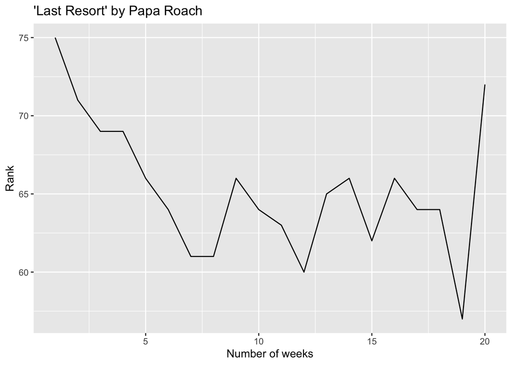

```r
df_billboard_tidy %>%
  filter(track == "Last Resort") %>%
ggplot(
  aes(x = week, y = rank)) +
  labs(title = "'Last Resort' by Papa Roach",
       x = "Number of weeks", y = "Rank") +
  geom_line()
```

# Heutige Ziele

Heute werden wir…

- die Maße der zentralen Tendenz (wieder) kennenlernen
- Streuungsmaße (neu) kennenlernen
- lernen, wie man die Funktion `summarise()` von `dplyr` benutzt
- lernen, wie man Zusammenfassungen `.by` Gruppe erstellt

## Lust auf mehr?

Ch.4, Section 4.5 [Groups](https://r4ds.hadley.nz/data-transform.html#groups) in Wickham et al. (o. J.)

# 1 Einrichtung

`Session > Restart R` um mit einer neuen Umgebung zu beginnen.

```r
pacman::p_load(tidyverse,
               here)
```

```r
df_flights <- read_csv(here("daten", "flights.csv"))
```

# 2 Deskriptive Statistik

- Die deskriptive Statistik beschreibt die zentrale Tendenz, die Variabilität und die Verteilung der Daten.
- manchmal auch “zusammenfassende” Statistik genannt, weil sie die beobachteten Daten *zusammenfasst*.

## 2.1 Anzahl der Werte ($n$)

- wichtige Informationen bei der Zusammenfassung von Daten
  - Wenn wir mehr Daten haben (höher $n$), haben wir mehr Vertrauen in die Schlussfolgerungen, die wir aus unseren Daten ziehen, weil wir mehr Beweise haben.
  - wird auch zur Berechnung einiger deskriptiver Statistiken verwendet

```r
values <- c(3,1,2)
length(values)
```

```
[1] 3
```

**`length()` versus `nrow()` and `n()`**

- die Funktion “Länge()” gibt an, wie viele (horizontale) Werte ein Objekt enthält
  - Wenn das Objekt ein Datenrahmen ist (statt eines Vektors wie “Werte”), sagt sie uns, wie viele *Spalten* wir haben.

```r
length(df_flights)
```

```
[1] 19
```

- Um die Anzahl der Werte (d.h. Beobachtungen/Zeilen) in einem Datenrahmen zu zählen, können wir verwenden
  - `nrow()` (Basis-R-Syntax), oder
  - `n()` (`dplyr`-Syntax), das werden wir später noch sehen

```r
nrow(df_flights)
```

```
[1] 336776
```

## 2.2 Maße der zentralen Tendenz

- ziemlich genau das, was wir für *numerische* Variablen mit der Funktion `summary()` erhalten

```r
df_flights %>%
  select(air_time, distance) %>%
  summary() %>%
  knitr::kable() %>%
  kableExtra::kable_styling(font_size = 30)
```

|  | air_time | distance |
| --- | --- | --- |
|  | Min. : 20.0 | Min. : 17 |
|  | 1st Qu.: 82.0 | 1st Qu.: 502 |
|  | Median :129.0 | Median : 872 |
|  | Mean :150.7 | Mean :1040 |
|  | 3rd Qu.:192.0 | 3rd Qu.:1389 |
|  | Max. :695.0 | Max. :4983 |
|  | NA's :9430 | NA |

### 2.2.1 Durchschnitt ($\mu$)

- `mean` = Mittelwert, Durchschnitt
- die Summe aller Werte geteilt durch die Anzahl der Werte

$$\mu = \frac{Summe\;der\;Werte}
{n}$$

- Wir können den Mittelwert leicht von Hand berechnen, wenn wir nur wenige Werte haben

```r
(3+1+2)/3
```

```
[1] 2
```

- wir können die Werte auch als Vektor (eine Liste von Werten derselben Klasse) speichern
- und dann die Funktion `mean()` verwenden, um ihren Mittelwert zu berechnen

```r
values <- c(3,1,2)
mean(values)
```

```
[1] 2
```

- oder wir können die Funktion `mean()` auf eine Variable in einem Datenrahmen anwenden
  - Verwendung des Zeichens `$`, um anzugeben, dass eine Spalte aus einem Datenrahmen ausgewählt werden soll

```r
mean(df_flights$distance)
```

```
[1] 1039.913
```

- `df_flights$distance` ist vergleichbar mit `df_flights %>% select(distance)`

### 2.2.2 Median

- `median` = Median, mediane Wert; der Wert in der Mitte des Datensatzes
- Wenn Sie alle Ihre Werte in aufsteigender (oder absteigender) Reihenfolge aneinanderreihen, ist der mittlere Wert der Median
  - Wenn Sie z. B. 5 Werte haben, ist der 3. Wert der Median
  - bei 6 Werten ist der Mittelwert aus dem 3. und 4. Wert der Median
- 50% der Daten liegen unter diesem Wert, 50% darüber

```r
median(df_flights$distance)
```

```
[1] 872
```

### 2.2.3 Modalwert

- `mode` = Modalwert; der Wert, der am häufigsten in einem Datensatz vorkommt
- Es gibt keine R-Funktion zur Bestimmung des “Modus”, aber wir können ihn mit einem Histogramm visualisieren

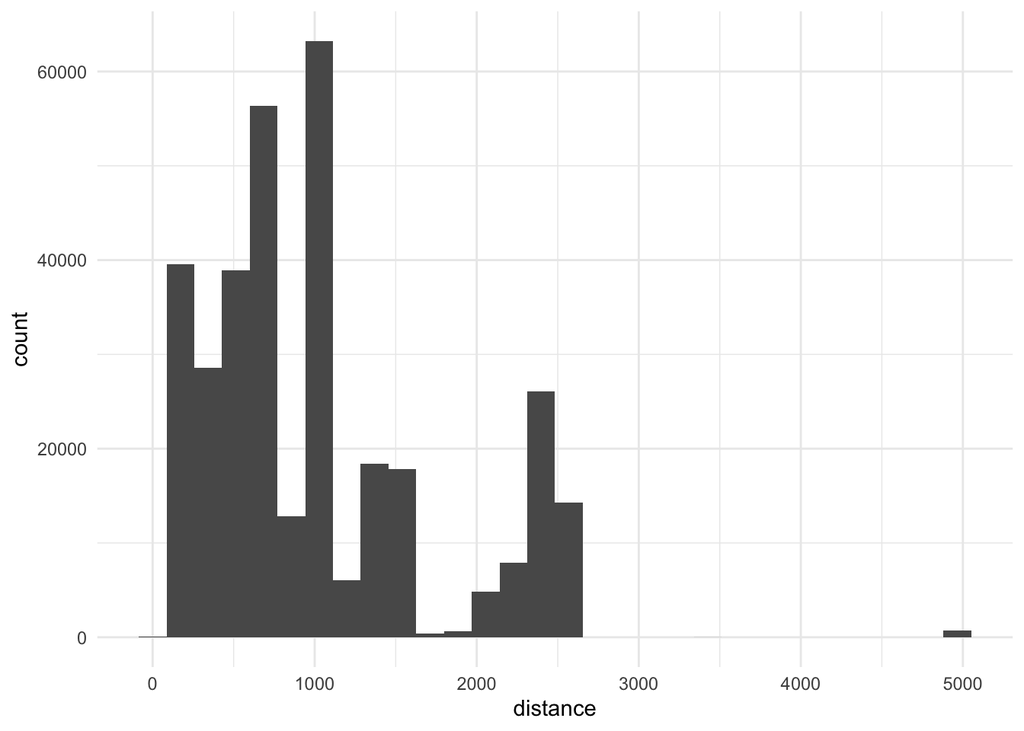

```r
df_flights %>%
  ggplot(aes(x = distance)) +
  geom_histogram() +
  theme_minimal()
```

## 2.3 Maße der Streuung

- Maße der zentralen Tendenz beschreiben die Mitte der Daten (normalerweise)
- Streuungsmaße beschreiben die Verteilung der Datenpunkte

### 2.3.1 Wertebereich

- `range` = Wertebereich
  - kann sich auf den höchsten und den niedrigsten Wert beziehen, oder
  - die Differenz zwischen höchstem und niedrigstem Wert
- `max()` und `min()` den höchsten und den niedrigsten Wert ausdrucken

```r
max(values)
```

```
[1] 3
```

```r
min(values)
```

```
[1] 1
```

- `range()` druckt den niedrigsten und den höchsten Wert

```r
range(values)
```

```
[1] 1 3
```

- können wir die Differenz zwischen diesen Werten berechnen:

```r
max(values) - min(values)
```

```
[1] 2
```

### 2.3.2 Standardabweichung (`sd` or $\sigma$)

- ein Maß dafür, wie gestreut die Daten *im Verhältnis zum Mittelwert* sind
  - eine niedrige Standardabweichung bedeutet, dass die Daten um den Mittelwert herum gruppiert sind (d. h. es gibt eine geringere Streuung)
  - eine hohe Standardabweichung bedeutet, dass die Daten stärker gestreut sind
- Die Standardabweichung wird sehr oft angegeben, wenn der Mittelwert angegeben wird.
- um `sd` zu berechnen
  - die Quadratwurzel ($\sqrt{}$) der Summe der quadrierten Wertabweichungen vom Mittelwert ($(x - \mu)^2$) geteilt durch die Anzahl der Beobachtungen minus 1 ($n-1$)

```r
sd(values)
```

```
[1] 1
```

- unsere Werte ($x$) sind:

```r
values
```

```
[1] 3 1 2
```

- der Mittelwert ($\mu$) ist:

```r
mean(values)
```

```
[1] 2
```

- die Anzahl der Werte ($n$) ist:

```r
length(values)
```

```
[1] 3
```

- die Standardabweichung ($\sigma$) ist:

```r
sd(values)
```

```
[1] 1
```

$$\begin{align}
\sigma & = \sqrt{\frac{(x_1-\mu)^2 + (x_2-\mu)^2 + (x_3-\mu)^2}{N-1}}
\\
& = \sqrt{\frac{(3-\mu)^2 + (1-\mu)^2 + (2-\mu)^2}{N-1}}
\\
& = \sqrt{\frac{(3-2)^2 + (1-2)^2 + (2-2)^2}{3-1}}
\\
& = \sqrt{\frac{(1)^2 + (-1)^2 + (0)^2}{2}}
\\
& = \sqrt{\frac{1 + 1 + 0}{2}}
\\
& = \sqrt{\frac{2}{2}} = \sqrt{1} = 1
\end{align}$$

- Inwiefern ist die Standardabweichung hilfreich?
  - Sie gibt uns ein Maß dafür, wie “eng” die beobachteten Werte am Mittelwert liegen.
- Verschiedene Datensätze können zum Beispiel denselben Mittelwert haben:

```r
values2 <- c(55,55,55,55,55,57,57,57,57,57)
values3 <- c(1,1,1,1,100,100,100,100,100)
```

```r
mean(values2)
```

```
[1] 56
```

```r
mean(values3)
```

```
[1] 56
```

- `values2` und `values3` haben den gleichen Mittelwert
  - Wenn wir nur den Mittelwert berechnen würden, könnten wir zu dem Schluss kommen, dass die Daten ähnlich sind.
- aber ihre Standardabweichungen werden sich unterscheiden, weil die beobachteten Werte alle unterschiedlich weit vom Mittelwert abweichen
- Welcher Vektor wird Ihrer Meinung nach die *geringste* Standardabweichung haben? Und warum?

```r
sd(values2)
```

```
[1] 1.054093
```

```r
sd(values3)
```

```
[1] 52.17758
```

**CBerechnung der Standardabweichung**

- Berechnen Sie zunächst die Abweichung jedes Wertes vom Mittelwert
  - und quadriere diesen Wert
- addiere alle diese quadrierten Abweichungswerte
  - dividiere durch die Anzahl der Beobachtungen *bis auf eine* ($n-1$)
- dies ist nun die *Varianz*, um die Standardabweichung der Population zu erhalten, berechnet man die Quadratwurzel dieses Wertes

$$\begin{align}
\sigma & = \sqrt\frac{(56-1)^2 + (56-1)^2 + (56-1)^2 + (56-1)^2 + (56-100)^2 +
(56-100)^2 + (56-100)^2 + (56-100)^2 + (56-100)^2 + (56-100)^2}{n-1}
\\
& = \sqrt{\frac{3025 + 3025 + 3025 + 3025 + 1936 + 1936 + 1936 + 1936 + 1936}{9-1}}
\\
& = \sqrt{\frac{21780}{8}}
\\
& = \sqrt{2722.5}
\\
& = 52.17758
\end{align}$$

- Da wir durch die Anzahl der Beobachtungen (minus 1) dividieren, wird die Standardabweichung kleiner sein, wenn wir *mehr* Beobachtungen haben (und daher durch eine größere Zahl dividieren) (denn wenn wir durch eine große Zahl dividieren, ist das Produkt viel kleiner)
- Beispiel: Wenn wir 100 durch die Zahl 2 teilen, ist das Ergebnis 50. Wenn wir 100 durch eine größere Zahl, wie 50, teilen, ist das Ergebnis (2) kleiner.

# 3 `dplyr::summarise()`

- berechnet Zusammenfassungen von Daten
  - aber wir müssen ihm sagen, *was* es berechnen soll und für welche Variable(n)

```r
df_flights %>%
  summarise(N = n())
```

```
# A tibble: 1 × 1
       N
   <int>
1 336776
```

- wir können auch mehrere Berechnungen auf einmal durchführen

```r
df_flights %>%
  summarise(mean_distance = mean(distance, na.rm=T),
            sd_distance = sd(distance, na.rm = T),
            N = n()) %>%
  knitr::kable() %>%
  kableExtra::kable_styling()
```

| mean_distance | sd_distance | N |
| --- | --- | --- |
| 1039.913 | 733.233 | 336776 |

- und wir können Berechnungen angeben

```r
df_flights %>%
  summarise(range_distance = max(distance) - min(distance))
```

```
# A tibble: 1 × 1
  range_distance
           <dbl>
1           4966
```

## 3.1 Fehlende Werte

- einige Berechnungen sind bei fehlenden Werten nicht möglich
  - die Variable “air_time” hat einige fehlende Werte

```r
df_flights %>%
  select(air_time, distance) %>%
  summary()
```

```
    air_time        distance
 Min.   : 20.0   Min.   :  17
 1st Qu.: 82.0   1st Qu.: 502
 Median :129.0   Median : 872
 Mean   :150.7   Mean   :1040
 3rd Qu.:192.0   3rd Qu.:1389
 Max.   :695.0   Max.   :4983
 NA's   :9430
```

```r
df_flights %>%
  summarise(mean_air_time = mean(air_time))
```

```
# A tibble: 1 × 1
  mean_air_time
          <dbl>
1            NA
```

- Bei der Arbeit mit realen Daten ist es nicht trivial, wie man mit fehlenden Werten umgeht.
  - z.B. könnten wir alle “N”-Werte in “0” umwandeln, wenn wir wollen, dass sie zur Berechnung des “Mittelwerts” beitragen
  - aber in den meisten Fällen wollen wir sie einfach entfernen (wie wir es schon oft getan haben)
- Wir können dies leicht mit dem `dplyr`-Verb `drop_na()` tun

```r
df_flights %>%
  drop_na() %>%
  summarise(mean = mean(air_time))
```

```
# A tibble: 1 × 1
   mean
  <dbl>
1  151.
```

# 4 Gruppierung von Variablen

- Wir wollen nicht immer nur die zusammenfassenden Statistiken für einen gesamten Datensatz kennen, aber
  - Wir wollen in der Regel bestimmte Gruppen *vergleichen* (z. B. den Vergleich von “Flugzeit” zwischen Fluggesellschaften).

## 4.1 `.by =`

- das brandneue Argument `.by =` in `summarise()` berechnet unsere Berechnungen auf gruppierten Teilmengen der Daten (erst ein paar Monate alt!)
  - Es nimmt eine “Variable” (d.h. einen Spaltennamen) und gruppiert nach den Ebenen dieser Variable

```r
df_flights %>%
  drop_na() %>%
  summarise(mean_air_time = mean(air_time),
            mean_distance = mean(distance),
            N = n(),
            .by = month) %>%
  arrange(mean_air_time)
```

```
# A tibble: 12 × 4
   month mean_air_time mean_distance     N
   <dbl>         <dbl>         <dbl> <int>
 1     9          143.         1049. 27010
 2     5          146.         1049. 28128
 3     7          147.         1070. 28293
 4     8          148.         1069. 28756
 5    10          149.         1042. 28618
 6     3          149.         1023. 27902
 7     6          150.         1074. 27075
 8     2          151.         1008. 23611
 9     4          153.         1048. 27564
10     1          154.         1014. 26398
11    11          155.         1052. 26971
12    12          163.         1076. 27020
```

## 4.2 Gruppieren nach mehreren Variablen

- Wir können auch nach mehreren Variablen gruppieren
  - Dazu benötigen wir `concatenate` (`c()`)
- wir filtern, um nur ein paar Träger zu haben, damit unsere Ausgabe nicht zu lang wird

```r
df_flights %>%
  drop_na() %>%
  filter(carrier %in% c("UA", "AA")) %>%
  summarise(mean_air_time = mean(air_time),
            mean_distance = mean(distance),
            N = n(),
            .by = c(month, carrier)) %>%
  arrange(month, carrier) %>%
  knitr::kable() %>%
  kableExtra::kable_styling(font_size = 20)
```

| month | carrier | mean_air_time | mean_distance | N |
| --- | --- | --- | --- | --- |
| 1 | AA | 199.5433 | 1353.099 | 2724 |
| 1 | UA | 213.7022 | 1463.894 | 4590 |
| 2 | AA | 197.9195 | 1352.686 | 2399 |
| 2 | UA | 207.4393 | 1437.190 | 4157 |
| 3 | AA | 192.3532 | 1349.525 | 2741 |
| 3 | UA | 204.7959 | 1454.933 | 4909 |
| 4 | AA | 192.9615 | 1343.950 | 2649 |
| 4 | UA | 212.0633 | 1504.828 | 4978 |
| 5 | AA | 183.4554 | 1341.822 | 2749 |
| 5 | UA | 209.1620 | 1559.828 | 4890 |
| 6 | AA | 183.4868 | 1338.606 | 2683 |
| 6 | UA | 213.0440 | 1580.517 | 4885 |
| 7 | AA | 178.3669 | 1328.671 | 2769 |
| 7 | UA | 207.8638 | 1581.408 | 4971 |
| 8 | AA | 179.4030 | 1326.186 | 2819 |
| 8 | UA | 212.0912 | 1593.323 | 5085 |
| 9 | AA | 179.3695 | 1344.793 | 2568 |
| 9 | UA | 208.0990 | 1571.911 | 4636 |
| 10 | AA | 186.8477 | 1337.230 | 2699 |
| 10 | UA | 210.3654 | 1528.576 | 5035 |
| 11 | AA | 193.3208 | 1344.323 | 2550 |
| 11 | UA | 218.2343 | 1534.453 | 4827 |
| 12 | AA | 200.7724 | 1361.288 | 2597 |
| 12 | UA | 224.2924 | 1546.725 | 4819 |

**`group_by()`**

- vor `.by()` haben wir das `dplyr`-Verb `group_by()` und `ungroup()` verwendet
  - Ich bevorzuge das neue `.by`, weil es die Gruppierung lokal hält (keine Notwendigkeit für `ungroup()`)
  - Behalten Sie dies im Hinterkopf, Sie könnten `group_by()` in freier Wildbahn sehen

```r
df_flights %>%
  drop_na() %>%
  filter(carrier %in% c("UA", "AA")) %>%
  group_by(month, carrier) %>%
  summarise(mean_air_time = mean(air_time),
            mean_distance = mean(distance),
            N = n()) %>%
  ungroup() %>%
  arrange(month, carrier) %>%
  head(n = 10) %>%
  knitr::kable() %>%
  kableExtra::kable_styling(font_size = 20)
```

| month | carrier | mean_air_time | mean_distance | N |
| --- | --- | --- | --- | --- |
| 1 | AA | 199.5433 | 1353.099 | 2724 |
| 1 | UA | 213.7022 | 1463.894 | 4590 |
| 2 | AA | 197.9195 | 1352.686 | 2399 |
| 2 | UA | 207.4393 | 1437.190 | 4157 |
| 3 | AA | 192.3532 | 1349.525 | 2741 |
| 3 | UA | 204.7959 | 1454.933 | 4909 |
| 4 | AA | 192.9615 | 1343.950 | 2649 |
| 4 | UA | 212.0633 | 1504.828 | 4978 |
| 5 | AA | 183.4554 | 1341.822 | 2749 |
| 5 | UA | 209.1620 | 1559.828 | 4890 |

# 5 Anscombe’s Quartet

- Francis Anscombe erstellte 1973 4 Datensätze, um zu zeigen, wie wichtig es ist, Daten zu visualisieren, bevor man sie analysiert und ein Modell erstellt
  - Diese vier Diagramme stellen 4 Datensätze dar, die alle einen nahezu identischen Mittelwert und eine Standardabweichung, aber sehr unterschiedliche Verteilungen aufweisen

Tabelle 1: Summary stats of Anscombe’s quratet datasets

| grp | mean_x | mean_y | min_x | min_y | max_x | max_y | crrltn |
| --- | --- | --- | --- | --- | --- | --- | --- |
| Group 1 | 9 | 7.500909 | 4 | 4.26 | 14 | 10.84 | 0.8164205 |
| Group 2 | 9 | 7.500909 | 4 | 3.10 | 14 | 9.26 | 0.8162365 |
| Group 3 | 9 | 7.500000 | 4 | 5.39 | 14 | 12.74 | 0.8162867 |
| Group 4 | 9 | 7.500909 | 8 | 5.25 | 19 | 12.50 | 0.8165214 |

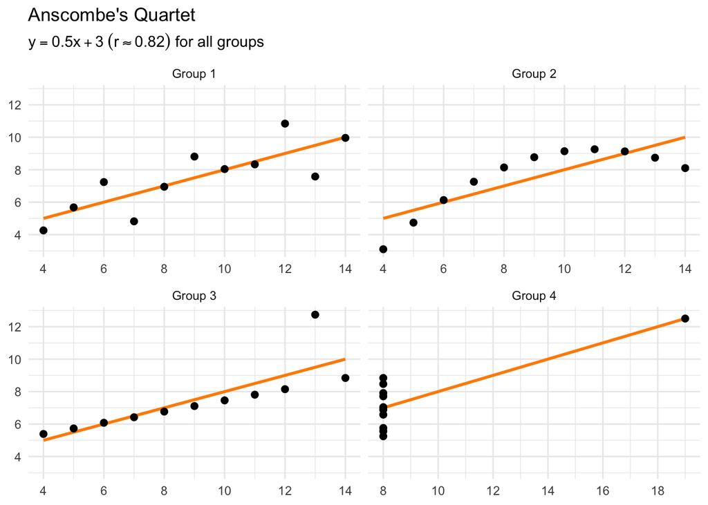

Abbildung 1: Plots of Anscombe’s quratet distributions

## 5.1 DatasaurRus

- das Paket `datasaurRus` enthält einige weitere Datensätze, die ähnliche Mittelwerte und SD, aber unterschiedliche Verteilungen aufweisen

```r
pacman::p_load("datasauRus")
```

```r
datasaurus_dozen %>%
    group_by(dataset) %>%
    summarize(
      mean_x    = mean(x),
      mean_y    = mean(y),
      std_dev_x = sd(x),
      std_dev_y = sd(y),
      corr_x_y  = cor(x, y)
    ) %>%
  knitr::kable() %>%
  kableExtra::kable_styling(font_size = 20)
```

Tabelle 2: Summary stats of datasauRus datasets

| dataset | mean_x | mean_y | std_dev_x | std_dev_y | corr_x_y |
| --- | --- | --- | --- | --- | --- |
| away | 54.26610 | 47.83472 | 16.76983 | 26.93974 | -0.0641284 |
| bullseye | 54.26873 | 47.83082 | 16.76924 | 26.93573 | -0.0685864 |
| circle | 54.26732 | 47.83772 | 16.76001 | 26.93004 | -0.0683434 |
| dino | 54.26327 | 47.83225 | 16.76514 | 26.93540 | -0.0644719 |
| dots | 54.26030 | 47.83983 | 16.76774 | 26.93019 | -0.0603414 |
| h_lines | 54.26144 | 47.83025 | 16.76590 | 26.93988 | -0.0617148 |
| high_lines | 54.26881 | 47.83545 | 16.76670 | 26.94000 | -0.0685042 |
| slant_down | 54.26785 | 47.83590 | 16.76676 | 26.93610 | -0.0689797 |
| slant_up | 54.26588 | 47.83150 | 16.76885 | 26.93861 | -0.0686092 |
| star | 54.26734 | 47.83955 | 16.76896 | 26.93027 | -0.0629611 |
| v_lines | 54.26993 | 47.83699 | 16.76996 | 26.93768 | -0.0694456 |
| wide_lines | 54.26692 | 47.83160 | 16.77000 | 26.93790 | -0.0665752 |
| x_shape | 54.26015 | 47.83972 | 16.76996 | 26.93000 | -0.0655833 |

- Wenn wir die Datensätze grafisch darstellen, sehen sie alle sehr unterschiedlich aus!

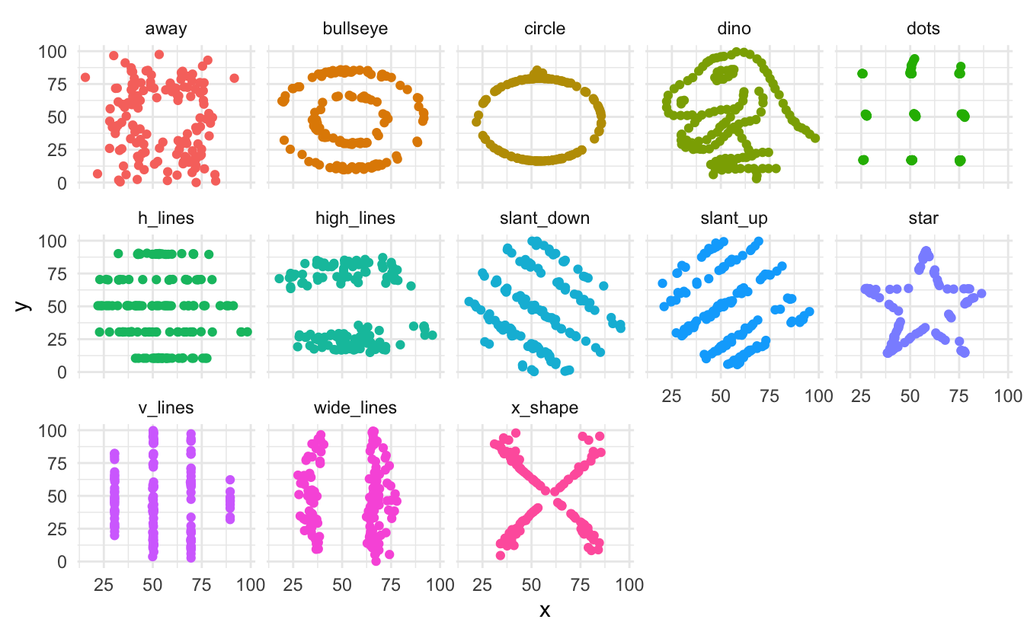

Abbildung 2: Plots of datasauRus dataset distributions

Stellen Sie Ihre Daten also immer grafisch dar und betrachten Sie nicht nur die beschreibenden Statistiken!!! Beides ist sehr wichtig für das Verständnis Ihrer Daten.

# 6 Aufgaben

1. Berechnen Sie die Standardabweichung der Werte `152, 19, 1398, 67, 2111`, ohne die Funktion `sd()` zu benutzen.
   - zeige deine Arbeit. Die folgende R-Syntax könnte nützlich sein (je nachdem, wie Sie es machen wollen):
     - `c()`
     - `Mittelwert()`
     - `x^2` berechnet das Quadrat eines Wertes (hier, `x`)
     - `sqrt()` berechnet die Quadratwurzel
     - `Länge()`
2. Benutze die Funktion `sd()`, um die Standardabweichung der obigen Werte zu drucken. Haben Sie es richtig gemacht?
3. Benutze `summarise`, um den Mittelwert, die Standardabweichung und die Anzahl der Beobachtungen für `dep_delay` zu drucken.
   - Hinweis: Müssen Sie fehlende Werte (`NA`) entfernen?
4. Machen Sie dasselbe, aber fügen Sie das Argument `.by()` hinzu, um die Abfahrtsverzögerung (`dep_delay`) pro Monat zu finden
   - Ordnen Sie die Ausgabe nach der mittleren Abflugverspätung an.
5. Drucke die Ausgabe mit einer schön formatierten Tabelle unter Verwendung von `knitr::kable()` und `kableExtra::kable_styling())`
   - eine Tabellenbeschriftung (`#| label: tbl-...`) und eine Tabellenüberschrift (`#| tbl-cap:`) einfügen
   - eine Beschreibung der Tabellenergebnisse, einschließlich eines Querverweises auf die Tabelle (`@tbl-...`)

# Heutige Ziele 🏁

Heute haben wir…

- Maße der zentralen Tendenz (neu) kennengelernt ✅
- (Wieder-)Erlernen von Streuungsmaßen ✅
- gelernt, wie man die Funktion `summarise()` von `dplyr` benutzt ✅
- gelernt, wie man Zusammenfassungen “nach” Gruppen erstellt ✅

# Session Info

Hergestellt mit R version 4.3.0 (2023-04-21) (Already Tomorrow) und RStudioversion 2023.3.0.386 (Cherry Blossom).

# Literaturverzeichnis

Wickham, H., Çetinkaya-Rundel, M., & Grolemund, G. (o. J.). *R for Data Science* (2. Aufl.). https://r4ds.hadley.nz/